# StackedModel

Delenn Bauer

2024-04-10

### Team: Neural Networkers

### Topic: Car Insurance Claims

### Github Repository: https://github.com/delennb/to628_openexplore.git

## Problem

In an increasingly competitive insurance market, the ability to accurately assess risk and set appropriate premiums is crucial. We’re going to use a hypothetical company called “M cAAr”, as our vehicle to illustrate the challenge of determining the likelihood of claims among its clientele. In this model we will outline the development of our predictive model designed to identify high-risk customers more accurately. The model integrates various predictors including demographic (illegal!), socioeconomic (also illegal?), driving history, and vehicle features. This approach not only aims to optimize financial outcomes for M cAAr, but also enhances customer satisfaction and retention by setting fair premiums based on predicted risk.

## Dataset

The predictive model was developed using a dataset of 10,000 car insurance claim records. This dataset included a diverse range of predictors, such as age, gender, race, income, education, driving experience, and vehicle type.

## Stacked Model

### Load Libraries and Data

We load the predictions from the various first-level models and combine them and the test data for further analysis into second-level stacked models.

```r
library(C50)
library(caret)
library(pROC)
```

```r
library(ggplot2)
library(ROCR)
source("addrow.R")

lr <- read.csv("lr_pred.csv")
knn <- read.csv("knn_pred.csv")
ann <- read.csv("ann_pred.csv")
dt <- read.csv("dt_pred.csv")
svm <- read.csv("svm_pred.csv")
rf <- read.csv("rf_pred.csv")

lr$X <- NULL
summary(lr)
```

```
##        x
##  Min.   :0.0000786
##  1st Qu.:0.0189125
##  Median :0.1498107
##  Mean   :0.3122552
##  3rd Qu.:0.5831512
##  Max.   :1.0000000
```

```r
knn$X <- NULL
summary(knn)
```

```
##        x
##  Min.   :0.5000
##  1st Qu.:0.6842
##  Median :0.8448
##  Mean   :0.8161
##  3rd Qu.:0.9483
##  Max.   :1.0000
```

```r
ann$X <- NULL
summary(ann)
```

```
##        V1
##  Min.   :-0.20983
##  1st Qu.: 0.01713
##  Median : 0.17235
##  Mean   : 0.30918
##  3rd Qu.: 0.59521
##  Max.   : 1.11328
```

```r
dt$X <- NULL
summary(dt)
```

```
##        x
##  Min.   :0.0000
##  1st Qu.:0.0000
##  Median :0.0000
##  Mean   :0.2875
##  3rd Qu.:1.0000
##  Max.   :1.0000
```

```r
summary(svm)
```

```
##        V1
##  Min.   :-0.136039
##  1st Qu.:-0.006147
##  Median : 0.069291
##  Mean   : 0.286626
##  3rd Qu.: 0.602154
##  Max.   : 1.171729
```

```r
summary(rf)
```

```
##        x
##  Min.   :0.0000
##  1st Qu.:0.0000
##  Median :0.0000
##  Mean   :0.3039
##  3rd Qu.:1.0000
##  Max.   :1.0000
```

```r
carinsurance_test <- read.csv("carinsurance_test.csv")

carinsurance_combined <- data.frame(lr$x, knn$x, ann$V1, dt$x, svm$V1, rf$x, carinsurance_test$OUTCOME1)
summary(carinsurance_combined)
```

```
##       lr.x               knn.x            ann.V1              dt.x
##  Min.   :0.0000786   Min.   :0.5000   Min.   :-0.20983   Min.   :0.0000
##  1st Qu.:0.0189125   1st Qu.:0.6842   1st Qu.: 0.01713   1st Qu.:0.0000
##  Median :0.1498107   Median :0.8448   Median : 0.17235   Median :0.0000
##  Mean   :0.3122552   Mean   :0.8161   Mean   : 0.30918   Mean   :0.2875
##  3rd Qu.:0.5831512   3rd Qu.:0.9483   3rd Qu.: 0.59521   3rd Qu.:1.0000
##  Max.   :1.0000000   Max.   :1.0000   Max.   : 1.11328   Max.   :1.0000
##      svm.V1               rf.x        carinsurance_test.OUTCOME1
##  Min.   :-0.136039   Min.   :0.0000   Min.   :0.0000
##  1st Qu.:-0.006147   1st Qu.:0.0000   1st Qu.:0.0000
##  Median : 0.069291   Median :0.0000   Median :0.0000
##  Mean   : 0.286626   Mean   :0.3039   Mean   :0.3133
##  3rd Qu.: 0.602154   3rd Qu.:1.0000   3rd Qu.:1.0000
##  Max.   : 1.171729   Max.   :1.0000   Max.   :1.0000
```

### Build Model

Our stacked model leverages two levels of models, using multiple machine learning algorithms, including Logistic Regression, Decision Trees, Artificial Neural Networks, k-Nearest Neighbors, Support Vector Machines, and Random Forests in the first level. The second level consists of a stacked model that combines predictions from the first-level models using a C5.0 decision tree.

```r
train_ratio <- 0.7
set.seed(12345)
train_rows <- sample(1:nrow(carinsurance_combined), train_ratio*nrow(carinsurance_combined))

train_2 <- carinsurance_combined[train_rows,]
test_2 <- carinsurance_combined[-train_rows,]

model_2 <- C5.0(as.factor(carinsurance_test.OUTCOME1) ~ ., data = train_2)

pred_2 <- predict(model_2, test_2)

comb_cm <- confusionMatrix(as.factor(pred_2), as.factor(test_2$carinsurance_test.OUTCOME1), positive = "1")
comb_cm
```

```
## Confusion Matrix and Statistics
##
##           Reference
## Prediction   0   1
##          0 421  48
##          1  80 185
##
##                Accuracy : 0.8256
##                  95% CI : (0.7962, 0.8524)
##     No Information Rate : 0.6826
##     P-Value [Acc > NIR] : < 2.2e-16
##
##                   Kappa : 0.6118
##
##  Mcnemar's Test P-Value : 0.006143
##
##             Sensitivity : 0.7940
##             Specificity : 0.8403
##          Pos Pred Value : 0.6981
##          Neg Pred Value : 0.8977
##              Prevalence : 0.3174
##          Detection Rate : 0.2520
##    Detection Prevalence : 0.3610
##       Balanced Accuracy : 0.8172
##
##        'Positive' Class : 1
##
```

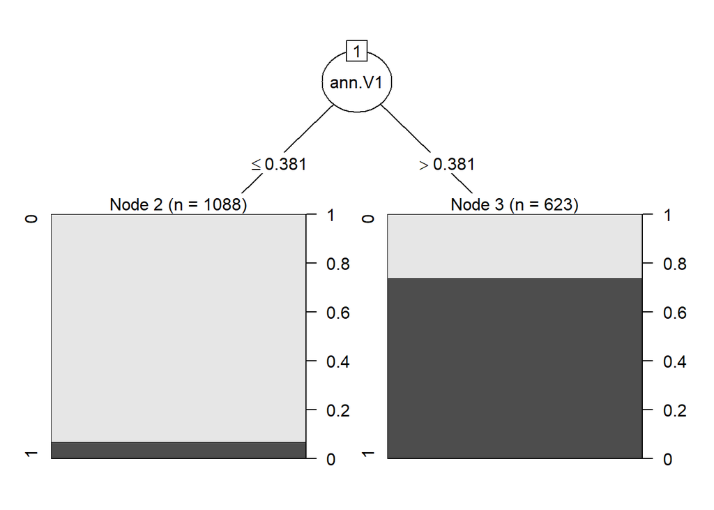

```r
plot(model_2)
```

As is shown in the decision tree plot of the basic stacked model above, this model only splits on the ANN first-level model, and doesn’t incorporate the other first-level models.

### Error Cost

A second stacked model was created that is cost-sensitive, allowing us to incorporate the financial aspect of the problem. We ensured that the model was trained with balanced costs to reflect the financial impacts of overcharging or undercharging customers, leading to a cost matrix setup where the penalty for a false negative was higher than that for a false positive.

```r
cost_matrix <- matrix(c(0,2,3,0), nrow = 2) # NEED TO UPDATE COST MATRIX

# False Positives (FP): If we predict a customer will file a claim, but they don't, the cost to the company is the additional resources spent on investigating and monitoring that customer. We assume around $500 per FP.
# False Negatives (FN): If we fail to predict a claim, and the customer does file one, the cost is the actual claim payout. Based on industry data, the average car insurance claim payout is about $5,000.

# cost_matrix <- matrix(c(0, 5000, 500, 0), nrow = 2)
cost_matrix
```

```
##      [,1] [,2]
## [1,]    0    3
## [2,]    2    0
```

```r
cost_model <-  C5.0(as.factor(carinsurance_test.OUTCOME1) ~ ., data = train_2, costs = cost_matrix)
```

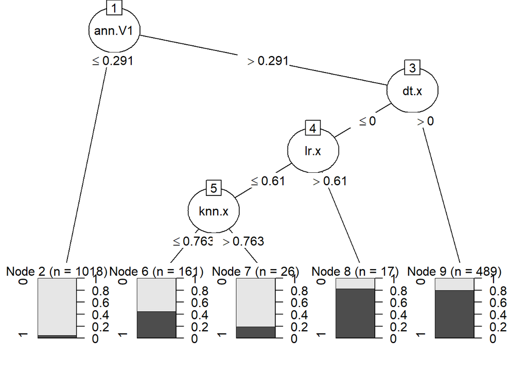

```r
plot(cost_model)
```

```r
pred_cost<- predict(cost_model, test_2)

cost_cm <- confusionMatrix(as.factor(pred_cost), as.factor(test_2$carinsurance_test.OUTCOME1), positive = "1")
cost_cm
```

```
## Confusion Matrix and Statistics
##
##           Reference
## Prediction   0   1
##          0 417  38
##          1  84 195
##
##                Accuracy : 0.8338
##                  95% CI : (0.8048, 0.86)
##     No Information Rate : 0.6826
##     P-Value [Acc > NIR] : < 2.2e-16
##
##                   Kappa : 0.6357
##
##  Mcnemar's Test P-Value : 4.619e-05
##
##             Sensitivity : 0.8369
##             Specificity : 0.8323
##          Pos Pred Value : 0.6989
##          Neg Pred Value : 0.9165
##              Prevalence : 0.3174
##          Detection Rate : 0.2657
##    Detection Prevalence : 0.3801
##       Balanced Accuracy : 0.8346
##
##        'Positive' Class : 1
##
```

The plot of the decision tree for the stacked cost model incorporates several of the first-level models, unlike the basic stacked model. Here we can see that the model splits on 4 of 6 of the first-level models, first splitting on ANN, then DT, LR, and KNN.

The cost matrix (as shown) used in the stacked cost model penalizes false positives by 2 and false negatives by 3. This weighting is consistent with the estimated costs for incorrect predictions within the larger context of the car insurance problem. Many other cost matrix penalty ratios were also tested, but this cost matrix maximized the performance of the model and other cost models resulted in significantly lower kappa values.

### Profit

We analyze the profit by considering the financial impact of true positives (correctly predicting claims) and false positives (incorrectly predicting claims). The profit is calculated based on the assumed claim payout and the cost of false positives.

```r
TN <- comb_cm$table[1,1]
FN <- comb_cm$table[1,2]
FP <- comb_cm$table[2,1]
TP <- comb_cm$table[2,2]

TNcost <- cost_cm$table[1,1]
FNcost <- cost_cm$table[1,2]
FPcost <- cost_cm$table[2,1]
TPcost <- cost_cm$table[2,2]

# Profit
comb_profit <- 5000*TP - 500*FP
comb_kappa <- comb_cm$overall["Kappa"]

cost_profit <- 5000*TPcost - 500*FPcost
cost_kappa <- cost_cm$overall["Kappa"]

# Normalize profit to 1000 entries
tot <- TN + FN + FP + TP
comb_profit <- (comb_profit / tot)*1000
cost_profit <- (cost_profit / tot)*1000
append_row(comb_kappa["Kappa"], comb_profit, "Stacked")
append_row(cost_kappa["Kappa"], cost_profit, "StackedCost")

comb_profit
```

```
## [1] 1205722
```

```r
comb_kappa
```

```
##    Kappa
## 0.611836
```

```r
cost_profit
```

```
## [1] 1271117
```

```r
cost_kappa
```

```
##     Kappa
## 0.6356787
```

## Summary of Model Performance

We summarize the performance of various models in terms of profit and Kappa statistic, which measures the agreement between predicted and actual outcomes.

```r
dataa <- read.csv("carinsurance_stats.csv")

# Split the single column into three columns based on space delimiter
split_data <- strsplit(dataa$RowName.kappa.profit, " ")

RowName <- sapply(split_data, "[", 1)
kappa <- as.numeric(sapply(split_data, "[", 2))
profit <- as.numeric(sapply(split_data, "[", 3))

# Summary Table of Model Performance
modeldata <- data.frame(
  Model = RowName,
  Profit = profit,
  Kappa = kappa
)

modeldata
```

```
##         Model    Profit     Kappa
## 1          LR 1101840.5 0.6391738
## 2         KNN  879754.6 0.5322007
## 3         ANN 1124744.4 0.6528780
## 4          DT 1106953.0 0.6528962
## 5          RF 1119018.4 0.6367809
## 6         SVM 1027402.9 0.5958071
## 7     Stacked 1205722.1 0.6118360
## 8 StackedCost 1271117.2 0.6356787
```

The table above provides a summary of the metrics for each of the models used - both first and second level. Most of the kappa values are all in the same range of around ~0.6, with the exception of KNN being a bit lower (~0.53). ANN and DT have the highest kappas of around ~0.65. In terms of the profit, all of the models except KNN are greater than $1 million. These profit values are all normalized to 1000 instances for consistency. Both stacked models result in higher profits than any of the individual models, with the stacked cost model generating the highest revenue of $1,271,117.20. This shows that overall, our stacked models did improve upon the first-level models. It makes sense that the stacked cost model generates the highest profit as it is the only model that takes the relative costs of incorrect predictions into account.

## Bar Chart

We visualize the profit and Kappa performance of different models using bar charts, distinguishing between first-level models and second-level stacked models.

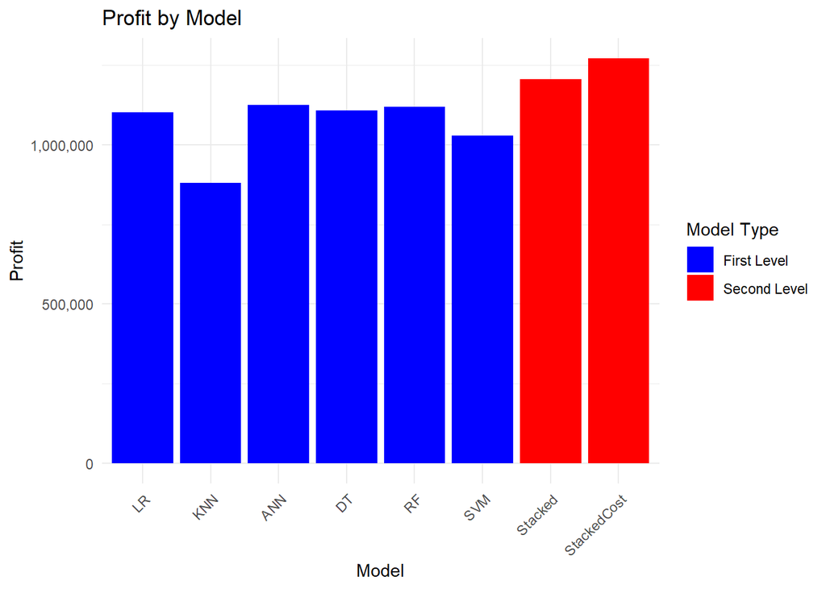

```r
# Set the order of levels in the Model variable
modeldata$Model <- factor(modeldata$Model, levels = c("LR", "KNN", "ANN", "DT", "RF", "SVM", "Stacked", "StackedCost"))

# Filter out the stacked and stacked cost models from the data
stacked_data <- subset(modeldata, Model %in% c("Stacked", "StackedCost"))

# Filter out the other models excluding stacked and stacked cost
other_models_data <- subset(modeldata, !(Model %in% c("Stacked", "StackedCost")))

profit_chart <- ggplot() +
  geom_bar(data = other_models_data, aes(x = Model, y = Profit, fill = "First Level"), stat = "identity") +
  geom_bar(data = stacked_data, aes(x = Model, y = Profit, fill = "Second Level"), stat = "identity") +
  geom_blank(aes(fill = "Second Level")) +  # Add blank layer for legend entry
  geom_blank(aes(fill = "First Level")) +   # Add blank layer for legend entry
  labs(y = "Profit", title = "Profit by Model") +
  theme_minimal() +
  theme(axis.text.x = element_text(angle = 45, hjust = 1)) +
  scale_fill_manual(values = c("First Level" = "blue", "Second Level" = "red"), guide = guide_legend(title = "Model Type")) +
  scale_y_continuous(labels = scales::comma)


# Create a bar chart for Kappa
kappa_chart <- ggplot() +
  geom_bar(data = other_models_data, aes(x = Model, y = Kappa, fill = "First Level"), stat = "identity") +
  geom_bar(data = stacked_data, aes(x = Model, y = Kappa, fill = "Second Level"), stat = "identity") +
  geom_blank(aes(fill = "Second Level")) +  # Add blank layer for legend entry
  geom_blank(aes(fill = "First Level")) +   # Add blank layer for legend entry
  labs(y = "Kappa", title = "Kappa by Model") +
  theme_minimal() +
  theme(axis.text.x = element_text(angle = 45, hjust = 1)) +
  scale_fill_manual(values = c("First Level" = "blue", "Second Level" = "red"), guide = guide_legend(title = "Model Type"))

# Show the bar charts
print(profit_chart)
```

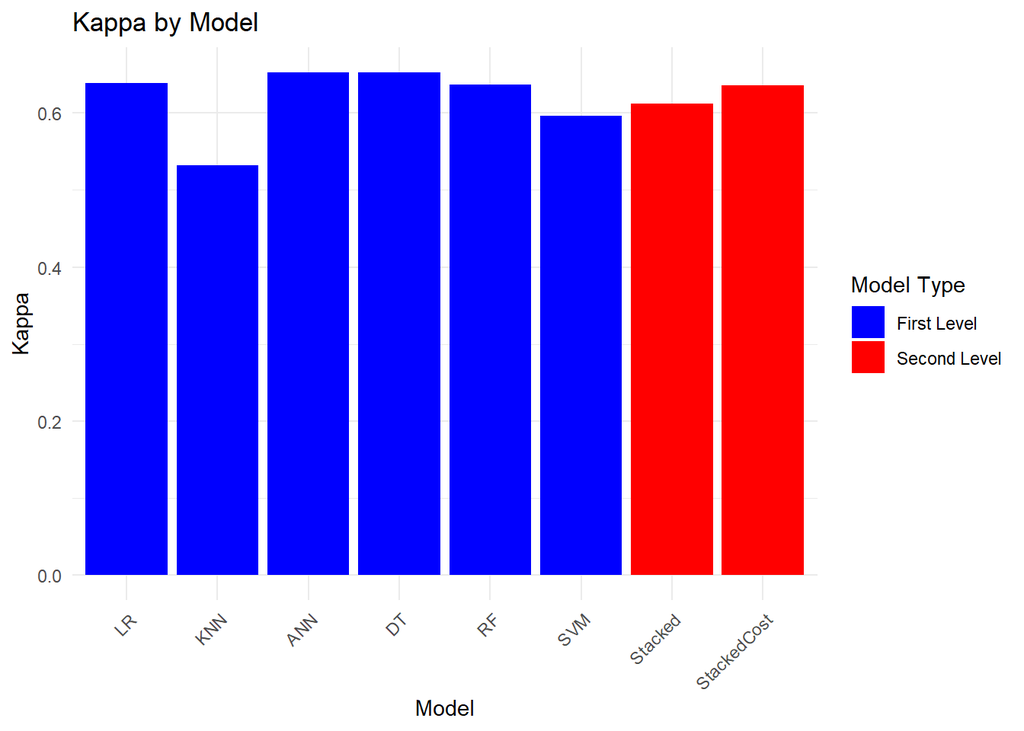

```r
print(kappa_chart)
```

As explained previously, these bar charts reaffirm the increased performance of the stacked models, especially the stacked cost model, over the first-level models. The profit values are higher and the kappa values are in a similar range to that of the first-level ones.

## ROC Curves for First-Level Models

We plot the ROC curves for different models to evaluate their performance in terms of true positive rate (sensitivity) and false positive rate (1-specificity).

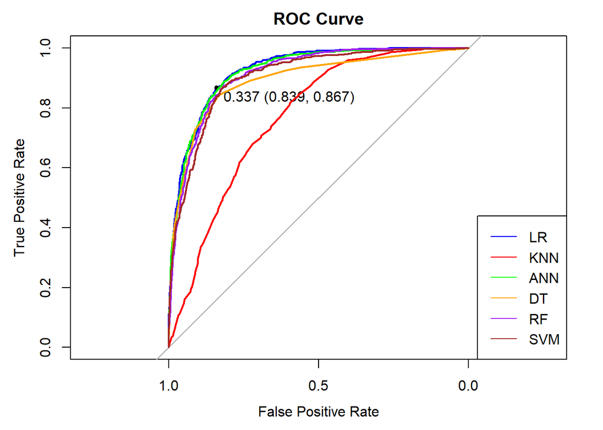

```r
# Calculate ROC curve for LR model
roc_lr <- roc(carinsurance_test$OUTCOME1, lr$x)
# Calculate ROC curve for KNN model
roc_knn <- roc(carinsurance_test$OUTCOME1, knn$x)
# Calculate ROC curve for ANN model
roc_ann <- roc(carinsurance_test$OUTCOME1, ann$V1)
# Calculate ROC curve for DT model
dt_prob <- read.csv("dt_pred_prob.csv")
# roc_dt <- roc(carinsurance_test$OUTCOME1, dt$x)
roc_dt <- roc(carinsurance_test$OUTCOME1, dt_prob$X1)
# Calculate ROC curve for RF model
rf_prob <- read.csv("rf_pred_prob.csv")
# roc_rf <- roc(carinsurance_test$OUTCOME1, rf_prob$X1)
# positive_class_prob <- rf_prob[, "1"]
roc_rf <- roc(carinsurance_test$OUTCOME1, rf_prob$X1)
# Calculate ROC curve for SVM model
roc_svm <- roc(carinsurance_test$OUTCOME1, svm$V1)
# Plot ROC curves
plot(roc_lr, col = "blue", main = "ROC Curve", xlab = "False Positive Rate", ylab = "True Positive Rate", print.thres = TRUE)
plot(roc_knn, col = "red", add = TRUE)
plot(roc_ann, col = "green", add = TRUE)
plot(roc_dt, col = "orange", add = TRUE)
plot(roc_rf, col = "purple", add = TRUE)
plot(roc_svm, col = "brown", add = TRUE)

# Add legend
legend("bottomright", legend = c("LR", "KNN", "ANN", "DT", "RF", "SVM"), col = c("blue", "red", "green", "orange", "purple", "brown"), lty = 1)
```

ROC curves of all of the first-level models were plotted to give insight into their discrimination capabilities and illustrate their performance. The majority of the models have decent discrimination capability as their curves tend toward the upper left hand corner of the plot rather than the grey line (representing random discrimination), meaning that they have relatively high AUC values. KNN performs somewhat worse than the other first-level models, as is shown by its curve being closer to the grey line.

## Savings

```r
# We can calculate the potential savings if our model can correctly identify the riskiest 10% of customers. We assume these customers account for a significant portion (50%) of total claims

total_claims <- nrow(carinsurance_test) * 0.3133  # assuming 31.33% claim rate from data
high_risk_claims <- total_claims * 0.5  # assuming 50% of claims come from top 10% riskiest
savings <- high_risk_claims * 5000  # savings from identifying and mitigating these claims
```

[output not shown]

## Risks and Challenges

The implementation of predictive models in risk assessment comes with its own set of challenges and risks:

- Bias and Fairness: As highlighted by the professor in class, the model must be constantly evaluated to avoid biases based on demographic and socioeconomic data, which could lead to discriminatory pricing, which is illegal.
- Dynamic Data: The model needs periodic updates as new data becomes available and driving behaviors/habits evolve, requiring ongoing maintenance and re-calibration. For example, if self driving cars are introduced to a set of customers that are included in the data, they would need to be accounted for.

## Conclusion

The predictive stacked model approach adopted by M cAAr demonstrates an advancement in risk assessment for car insurance. By accurately identifying high-risk customers, the company can set premiums more effectively, thus maximizing profit while minimizing risks. The highest profit/savings achieved with the stacked cost model indicates its ability to influence M cAAr’s business performance. This model promises improved financial outcomes, and also better customer relationships through fair pricing.